# [Back to Course Website](http://ericdunford.com/ppol670/) Data Visualization

PPOL 670 | Introduction to Data Science Lecture Materials for Week 5

Professor Eric Dunford (ed769@georgetown.edu) McCourt School of Public Policy, Georgetown University

# Learning Objectives

**In the Asynchronous Lecture**

- Understanding the **components** of a good quantitative visualization
- An introduction to the **grammar of graphics** (`ggplot2`)
- Delving into the different **`geom`etric projections** available to you when visualizing:
  - continuous on continuous data;
  - continuous on categorical data; and
  - categorical on categorical data.
- Tweaking aesthetics with **themes** and **scales**.
- Combining many plots with **`facet`ing** and `patchwork`

**In the Synchronous Lecture**

- Further develop our understanding of the `ggplot2` package with an **applied walkthrough**
- Discuss how to **export `ggplot2` graphics**.
- Discover some **third-party packages** that make specific visualization tasks easier.

> If you have any questions while watching the pre-recorded material, be sure to **write them down and to bring them up** during the synchronous portion of the lecture.

# Asynchronous Materials

*The following tabs contain pre-recorded lecture materials for class this week. Please review these materials prior to the synchronous lecture.*

*Total time*: Approx. 1 hour and 12 minutes

## _

## Visualizing Data

### [**Relevant Slides**](http://ericdunford.com/ppol670/Lectures/week_05/lecture-week-05_data-visualization.html#3)

[interactive chart not shown]

## Grammar of Graphics

### [**Relevant Slides**](http://ericdunford.com/ppol670/Lectures/week_05/lecture-week-05_data-visualization.html#16)

[interactive chart not shown]

### Code from the video

```r
require(tidyverse)

# Data ------------------------------------------------------------------

# Simulated Data
set.seed(1234)
dat <-
  tibble::tibble(var1 = rnorm(100),
                 var2 = var1 + rnorm(100))

summary(dat)


# Grammar of Graphics --------------------------------------------------
ggplot(data = dat, aes(x = var1, y = var2, color = var1)) +
  geom_point()
```

## Continuous Data

[interactive chart not shown]

### Code from the video

```r
require(tidyverse)

# Data --------------------------------------------------------------------

# Simulated Data
set.seed(1234)
dat <-
  tibble::tibble(var1 = rnorm(1000),
                 var2 = var1 + rnorm(1000))

summary(dat)

dat


# Continuous Univariate -----------------------------------------------------

# Histogram
ggplot(data = dat, aes(x = var1)) +
  geom_histogram()


# Density Plot
ggplot(data = dat, aes(x = var1)) +
  geom_density(fill="blue",color="white",alpha=.5)

# Continuous Bivariate ----------------------------------------------------

# Scatter Plot
ggplot(data = dat, aes(x = var1, y = var2)) +
  geom_point()


# Line Plot
ggplot(data = dat, aes(x = var1, y = var2)) +
  geom_line()


# Density Plot (in 2 Dimensions)
ggplot(data = dat, aes(x = var1, y = var2)) +
  geom_density_2d()

# Same thing filled
ggplot(data = dat, aes(x = var1, y = var2)) +
  geom_density_2d_filled()

# Hex Plot
ggplot(data = dat, aes(x = var1, y = var2)) +
  geom_hex()


# Layering Geoms ----------------------------------------------------

ggplot(data = dat, aes(x = var1, y = var2)) +
  geom_point() +
  geom_hex(alpha=.7)
```

## Categorical Data

[interactive chart not shown]

### Code from the video

```r
require(tidyverse)
library(palmerpenguins) # https://github.com/allisonhorst/palmerpenguins

    # Includes measurements for penguin species, island in Palmer Archipelago,
    # size (flipper length, body mass, bill dimensions), and sex. This is a
    # subset of penguins_raw.


# Data --------------------------------------------------------------------

dat <- penguins

summary(dat)



# Univariate Categorical --------------------------------------------------


# Bar Plot
ggplot(dat,aes(x=species)) +
  geom_bar()


# Ordering Bar Plot by Frequency
ggplot(dat,aes(x=fct_infreq(species))) +
  geom_bar()


# Adding in more categorical data
ggplot(dat,aes(x=fct_infreq(species), fill = sex)) +
  geom_bar()


# Stacking vs. Dodge
ggplot(dat,aes(x=fct_infreq(species), fill = sex)) +
  geom_bar(position="dodge")



# Bivariate: category on continuous -----------------------------------------


# Box plot
ggplot(dat,aes(x=body_mass_g,y = species)) +
  geom_boxplot()


# Violin plot
ggplot(dat,aes(x=body_mass_g,y = species)) +
  geom_violin()


# Jitter plot
ggplot(dat,aes(x=body_mass_g,y = species)) +
  geom_jitter(height = .05,alpha=.5)


# Layer the representations
ggplot(dat,aes(x=body_mass_g,y = species)) +
  geom_jitter(height = .15) +
  geom_violin(alpha=.5)


# Trivariate: category on category on continous -----------------------------------------

dat %>%
  drop_na() %>%
  ggplot(aes(x=sex,y = species,fill=body_mass_g)) +
  geom_tile()


# Trivariate: category on category on continous -----------------------------------------

dat %>%
  ggplot(aes(x=bill_length_mm,
             y = flipper_length_mm,
             color=species)) +
  geom_point()
```

## Many Plots

[interactive chart not shown]

### Code from the video

```r
require(tidyverse)
require(patchwork) # for combining plots
require(palmerpenguins) # https://github.com/allisonhorst/palmerpenguins

    # Includes measurements for penguin species, island in Palmer Archipelago,
    # size (flipper length, body mass, bill dimensions), and sex. This is a
    # subset of penguins_raw.


# Data --------------------------------------------------------------------

dat <- penguins

summary(dat)


# Many Plots with Faceting -----------------------------------------


  ggplot(dat,
         aes(x=bill_length_mm,
             y = flipper_length_mm,
             color=species)) +
    geom_point()


  # Break plots up by category with facets
  ggplot(dat,
         aes(x=bill_length_mm,
             y = flipper_length_mm,
             color=species)) +
    geom_point() +
    facet_wrap(~species)


  # Adjust scales on the facets
  ggplot(dat,
         aes(x=bill_length_mm,
             y = flipper_length_mm,
             color=species)) +
    geom_point() +
    facet_wrap(~species,scales = "free")


  # Facet along more than one category
  ggplot(drop_na(dat),
         aes(x=bill_length_mm,
             y = flipper_length_mm,
             color=species)) +
    geom_point() +
    facet_wrap(~species + sex)


  # Specify the columns and rows
  ggplot(drop_na(dat),
         aes(x=bill_length_mm,
             y = flipper_length_mm,
             color=species)) +
    geom_point() +
    facet_wrap(~species + sex,scales = "free",ncol = 2)



# Combine Plots with Patchwork --------------------------------------------

  plt1 <-
    ggplot(dat,aes(x=bill_length_mm,
                   y=flipper_length_mm)) +
    geom_point()
  plt1

  plt2 <-
    ggplot(dat,aes(x=fct_infreq(species), fill = sex)) +
    geom_bar(position="dodge")
  plt2


  # Combine them with patchwork
  plt1 + plt2

  # Arrange them
  plt1 + plt2 + plot_layout(ncol = 1)


  # resize them
  plt1 + plt2 + plot_layout(ncol = 1,heights = c(.25,.75))


  # sky is the limit
  plt1 + plt2 + plt2 + plt1
```

## Customizing Plots

[interactive chart not shown]

### Code from the video

```r
require(tidyverse)
require(palmerpenguins) # https://github.com/allisonhorst/palmerpenguins

    # Includes measurements for penguin species, island in Palmer Archipelago,
    # size (flipper length, body mass, bill dimensions), and sex. This is a
    # subset of penguins_raw.


# Data --------------------------------------------------------------------

dat <- penguins

summary(dat)


# Customizing Plot Aesthetics -----------------------------------------

ggplot(dat,
       aes(x=bill_length_mm,
           y = flipper_length_mm,
           color=species)) +
  geom_point(size=3,alpha=.75) +
  scale_color_manual(values = c("darkred","steelblue","grey30")) +
  theme_classic() +
  labs(x = "Bill Length (mm)",y="Flipper Length (mm)",color="") +
  theme(legend.position = "top")
```

# Practice

These exercises are designed to help you reinforce your grasp of the concepts covered in the asynchronous lecture material.

For the following questions, we’ll use the `diamonds` dataset, which comes installed when we import the `ggplot2` package. The dataset contains the prices and other attributes of 54,000 diamonds. The dataset is useful for visualization purposes.

```r
require(tidyverse)
dat <- diamonds
head(dat)
```

```
## # A tibble: 6 x 10
##   carat cut       color clarity depth table price     x     y     z
##   <dbl> <ord>     <ord> <ord>   <dbl> <dbl> <int> <dbl> <dbl> <dbl>
## 1 0.23  Ideal     E     SI2      61.5    55   326  3.95  3.98  2.43
## 2 0.21  Premium   E     SI1      59.8    61   326  3.89  3.84  2.31
## 3 0.23  Good      E     VS1      56.9    65   327  4.05  4.07  2.31
## 4 0.290 Premium   I     VS2      62.4    58   334  4.2   4.23  2.63
## 5 0.31  Good      J     SI2      63.3    58   335  4.34  4.35  2.75
## 6 0.24  Very Good J     VVS2     62.8    57   336  3.94  3.96  2.48
```

## _

## Question 1

Using the `diamonds` data, plot the distribution of the different `cut` categories. Customize the plot as follows:

- Change the `fill` of the bars be `"steelblue"`;
- Change the theme of plot to be `minimal`;
- Add a title using `labs()` that reads “Diamond Cuts”

### _

### Answer

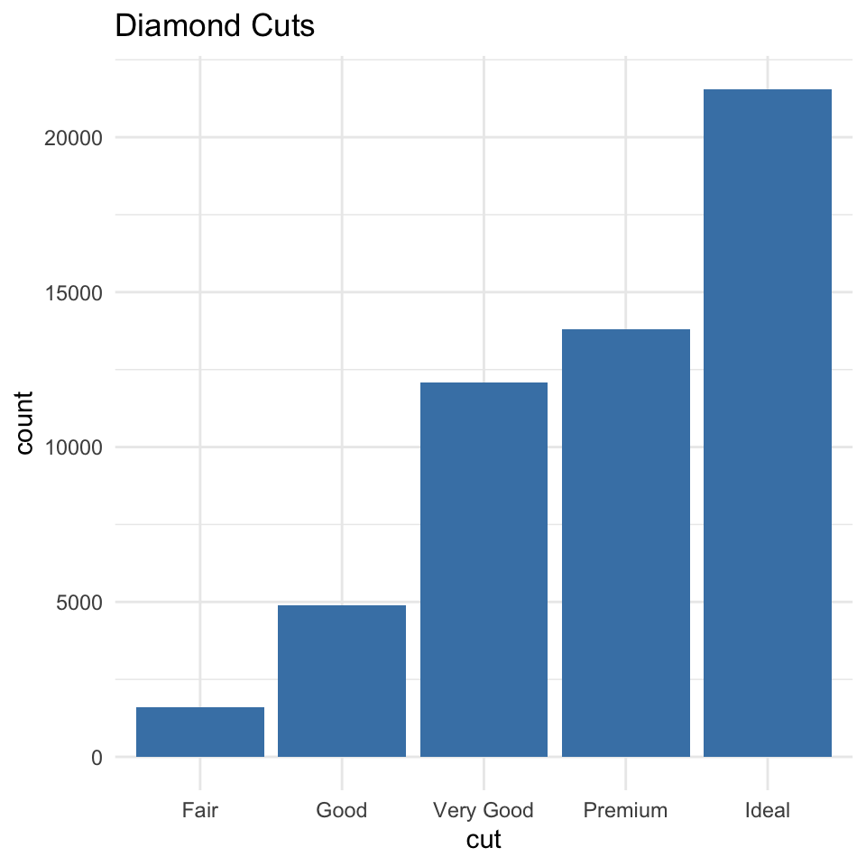

```r
ggplot(dat,aes(x=cut)) +
  geom_bar(fill='steelblue') +
  labs(title = "Diamond Cuts") +
  theme_minimal()
```

## Question 2

Do the following:

- Create a new variable in the `diamonds` data called `expensive` that takes on the value of `"yes"` if the price is above the average price of a diamond, `"no"` otherwise.
- Using the same code you used to generate the plot in Q1, use this variable to break up each category into expensive and non-expensive stacks using the `"dodge"` position (see the video on categorical data).
- When `expensive == "yes"` the bars should be filled `orange`, and `grey30` otherwise.

### _

### Answer

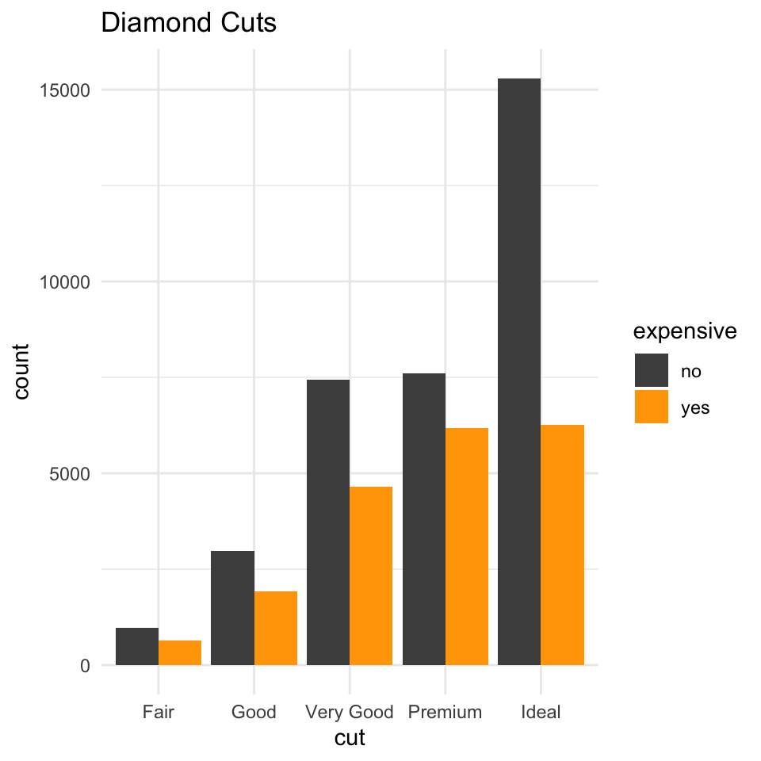

```r
dat %>%
  mutate(expensive = ifelse(price > mean(price),"yes","no")) %>%
  ggplot(aes(x=cut,fill=expensive)) +
  geom_bar(position="dodge") +
  scale_fill_manual(values = c("grey30","orange")) +
  labs(title = "Diamond Cuts") +
  theme_minimal()
```

## Question 3

Using the `diamonds` data, plot `price` on `carat` using points, and do the following:

- Make the points transparent using `alpha = .25`;
- Color each point by `cut`.
- Facet the plots by `cut` and arrange the facet plots so that you only have 1 row;
- Change the labels so that the legend reads “Diamond Cut”, the x-axis reads “Price ($)” and the y-axis reads “Carat”.
- Change the theme to `classic`;
- Change the position of the legend so that it’s on the `"bottom"` of the plot.

### _

### Answer

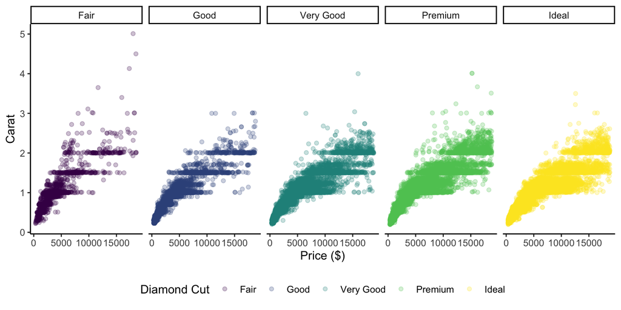

```r
dat %>%
  ggplot(aes(price, carat, color= cut)) +
  geom_point(alpha=.25) +
  facet_wrap(~cut,nrow=1) +
  labs(color="Diamond Cut",x = "Price ($)",y="Carat") +
  theme_classic() +
  theme(legend.position = "bottom")
```

*The following materials were generated for students enrolled in PPOL670. Please do not distribute without permission.*

*ed769@georgetown.edu | www.ericdunford.com*